# Informe Análisis Podrán

Alexia Aquino

2025-10-31

## Procedimiento de análisis en R

# Base utilizada para análisis de los participantes

```r
datos <- readr::read_csv("base_analisis_unificado_podran.csv",
  na = "NA"
) |>
  janitor::clean_names()
```

## Bases utilizadas para analisis relacional de participantes y facilitadores

```r
participantes <- readr::read_csv("base_analisis_unificado_podran.csv") |>
  janitor::clean_names()

facilitadores <- readr::read_csv("base_analisis_facilitadores.csv") |>
  janitor::clean_names()
```

## Categorización de variables de participantes

```r
# Estandarizar NAs si quedaron como texto
datos <- datos |>
  mutate(
    # Definir factores (Factor)
    dem_genero = factor(dem_genero, levels = c("F", "M", "NB")),
    dem_grupo = factor(dem_grupo, levels = c("A", "B")),
    dem_caso = factor(dem_caso, levels = c("AMBIENTE", "DESARROLLO", "EDUCACION", "CIENCIA", "SEGURIDAD")),
    municipio = factor(municipio),

    # Convertir a numérico (si no lo hizo readr, aunque los datos ya lo eran)
    # Si estas columnas ya son dbl, as.numeric() simplemente confirma el tipo.
    dem_edad = as.numeric(dem_edad),
    dem_curso_sec = as.numeric(dem_curso_sec)
  )
```

# 1) Variables sociodemográficas

```r
variables_demograficas <- c("dem_genero", "dem_edad",
                            "dem_curso_sec", "municipio")
```

# 2) Variables de diseño del juego / Intervención

```r
variables_juego <- c(
  "dem_grupo",     # Asignación Experimental/Control
  "dem_caso",      # Tema de la Intervención
  "dem_mesa",      # ID de la mesa
  "dem_num_mesa"   # Número dentro de la mesa
)
```

# 3) Subset de variables para análisis de regresión

```r
# Variables de Interés (Efectos Fijos - VI)
variables_independientes <- c("dem_grupo", "dem_caso")

# Variables de Control (Covariables - COV)
variables_control <- c("dem_genero", "dem_edad")
```

# Agrupación de items en vectores según cuestionario

# 1) Definir vector de ítems reverse e invertirlos

```r
items_inversos <- c(
 "d_imputab_16_pre", "d_mineria_prohib_pre", "d_protec_sinprecio_pre", "d_editgen_sinprob_pre",
"d_imputab_16_post", "d_mineria_prohib_post", "d_protec_sinprecio_post", "d_editgen_sinprob_post",
"b_perspec_dific_r")

# ===============================
# Invertir los ítems (escala 1–5) y crear columnas *_inv
# Se usa as.numeric(.) para asegurar que la operación 6 - x sea correcta
datos <- datos |>
 mutate(across(all_of(items_inversos), ~ 6 - as.numeric(.), .names = "{.col}_inv"))
```

# 2) Vectores de cuestionarios completos

```r
# --- Cuestionario A: Pensamiento Crítico (Total) ---
pensamiento_critico <- c(
 "a_arg_articul", "a_evid_datos", "a_incoher_det",
 "a_concl_logica", "a_puntos_vista", "a_perspec_verac"
)

# --- Cuestionario B: Empatía Cognitiva (con ítem invertido) ---
# Nota: b_perspec_dific_r se usa en su versión *_inv
empatia <- c(
 "b_perspec_dific_r_inv", "b_confl_lados", "b_amigos_enluga",
 "b_dos_parte", "b_poner_luga", "b_antes_criticar"
)

# --- Cuestionario C: Compromiso democratico (Total) ---
compromiso_democratico <- c(
 "c_discu_reunion", "c_arg_contra", "c_org_grupo", "c_debates_part",
 "c_sosten_invo", "c_imp_jovenes", "c_impacto_soc", "c_dialogo_tol"
)

# --- Cuestionario D: Conocimiento General (pre y post) ---
conocimiento_pre <- c(
 "d_uni_ingreso_pre", "d_uni_impuestos_pre", "d_delito_factores_pre",
 "d_mineria_riesgos_pre", "d_protec_arancel_pre", "d_editgen_preven_pre",
 "d_imputab_16_pre_inv", "d_mineria_prohib_pre_inv",
 "d_protec_sinprecio_pre_inv", "d_editgen_sinprob_pre_inv"
)

conocimiento_post <- c(
 "d_uni_ingreso_post", "d_uni_impuestos_post", "d_delito_factores_post",
 "d_mineria_riesgos_post", "d_protec_arancel_post", "d_editgen_preven_post",
 "d_imputab_16_post_inv", "d_mineria_prohib_post_inv",
 "d_protec_sinprecio_post_inv", "d_editgen_sinprob_post_inv"
)
```

# 3) Vectores de conocimiento por caso (2 ítems por caso pre y post)

```r
# --- AMBIENTE (Minería) ---
con_ambiente_pre <- c("d_mineria_riesgos_pre", "d_mineria_prohib_pre_inv")
con_ambiente_post <- c("d_mineria_riesgos_post", "d_mineria_prohib_post_inv")

# --- CIENCIA (Edición genética) ---
con_ciencia_pre  <- c("d_editgen_preven_pre",  "d_editgen_sinprob_pre_inv")
con_ciencia_post <- c("d_editgen_preven_post", "d_editgen_sinprob_post_inv")

# --- DESARROLLO (Proteccionismo) ---
con_desarrollo_pre <- c("d_protec_arancel_pre",  "d_protec_sinprecio_pre_inv")
con_desarrollo_post <- c("d_protec_arancel_post", "d_protec_sinprecio_post_inv")

# --- EDUCACION (Universidad / impuestos) ---
con_educacion_pre <- c("d_uni_ingreso_pre", "d_uni_impuestos_pre")
con_educacion_post <- c("d_uni_ingreso_post", "d_uni_impuestos_post")

# --- SEGURIDAD (Imputabilidad / factores del delito) ---
con_seguridad_pre <- c("d_delito_factores_pre", "d_imputab_16_pre_inv")
con_seguridad_post <- c("d_delito_factores_post", "d_imputab_16_post_inv")
```

# Función para calcular puntajes totales y promedio por cada cuestionario

```r
# 1. Funciones auxiliares: USAN NA.RM = TRUE para ignorar NA's en la suma/promedio
calcular_suma <- function(vars) {
  # rowSums suma solo los valores que existen
  rowSums(across(all_of(vars)), na.rm = TRUE)
}

calcular_promedio <- function(vars) {
  # rowMeans promedia solo los valores que existen
  rowMeans(across(all_of(vars)), na.rm = TRUE)
}
```

# Variables de puntaje total y promedio de cada cuestionario

```r
datos <- datos |>
  rowwise() |> # Aplicar cálculos fila por fila
  mutate(
    # =========================================================

    # --- Pensamiento Crítico ---
    total_pensamiento_critico       = calcular_suma(pensamiento_critico),
    pensamiento_critico_promedio    = calcular_promedio(pensamiento_critico),

    # --- Empatía ---
    total_empatia                   = calcular_suma(empatia),
    empatia_promedio                = calcular_promedio(empatia),

    # --- Compromiso democratico ---
    total_compromiso_democratico         = calcular_suma(compromiso_democratico),
    compromiso_democratico_promedio      = calcular_promedio(compromiso_democratico),

    # =========================================================
    # 3. CONOCIMIENTO GENERAL (Suma y Delta)
    # =========================================================

    # Scores Totales (Suma de todos los ítems de conocimiento)
    conocimiento_general_pre_total  = calcular_suma(conocimiento_pre),
    conocimiento_general_post_total = calcular_suma(conocimiento_post),

    # Delta General (Total Post - Total Pre)
    delta_conocimiento_general      = conocimiento_general_post_total - conocimiento_general_pre_total,

    # Puntajes Promedio
    conocimiento_general_pre_promedio  = calcular_promedio(conocimiento_pre),
    conocimiento_general_post_promedio = calcular_promedio(conocimiento_post),

    # =========================================================
    # 4. CONOCIMIENTO ESPECÍFICO POR CASO (Suma Pre, Suma Post, Delta)
    # =========================================================

    # --- AMBIENTE (Minería) ---
    con_ambiente_pre_total    = calcular_suma(con_ambiente_pre),
    con_ambiente_post_total   = calcular_suma(con_ambiente_post),
    delta_con_ambiente        = con_ambiente_post_total - con_ambiente_pre_total,
    con_ambiente_pre_promedio    = calcular_promedio(con_ambiente_pre),
    con_ambiente_post_promedio   = calcular_promedio(con_ambiente_post),

    # --- CIENCIA (Edición genética) ---
    con_ciencia_pre_total     = calcular_suma(con_ciencia_pre),
    con_ciencia_post_total    = calcular_suma(con_ciencia_post),
    delta_con_ciencia         = con_ciencia_post_total - con_ciencia_pre_total,
    con_ciencia_pre_promedio     = calcular_promedio(con_ciencia_pre),
    con_ciencia_post_promedio    = calcular_promedio(con_ciencia_post),

    # --- DESARROLLO (Proteccionismo) ---
    con_desarrollo_pre_total  = calcular_suma(con_desarrollo_pre),
    con_desarrollo_post_total = calcular_suma(con_desarrollo_post),
    delta_con_desarrollo      = con_desarrollo_post_total - con_desarrollo_pre_total,
    con_desarrollo_pre_promedio  = calcular_promedio(con_desarrollo_pre),
    con_desarrollo_post_promedio = calcular_promedio(con_desarrollo_post),

    # --- EDUCACION (Universidad / impuestos) ---
    con_educacion_pre_total   = calcular_suma(con_educacion_pre),
    con_educacion_post_total  = calcular_suma(con_educacion_post),
    delta_con_educacion       = con_educacion_post_total - con_educacion_pre_total,
    con_educacion_pre_promedio   = calcular_promedio(con_educacion_pre),
    con_educacion_post_promedio  = calcular_promedio(con_educacion_post),

    # --- SEGURIDAD (Imputabilidad / factores del delito) ---
    con_seguridad_pre_total   = calcular_suma(con_seguridad_pre),
    con_seguridad_post_total  = calcular_suma(con_seguridad_post),
    delta_con_seguridad       = con_seguridad_post_total - con_seguridad_pre_total,
    con_seguridad_pre_promedio   = calcular_promedio(con_seguridad_pre),
    con_seguridad_post_promedio  = calcular_promedio(con_seguridad_post)
  ) |>
  ungroup() # Volver al modo normal de dataframe
```

# Análisis Descriptivo de la Muestra

```r
library(dplyr)
library(janitor)
library(tidyr)
library(gtsummary)

# A. Cantidad Total de Participantes
n_total <- nrow(datos)

# B. Frecuencias de Variables de Diseño (Juego)
frec_grupo <- datos |> tabyl(dem_grupo)
frec_municipio <- datos |> tabyl(municipio)
frec_caso <- datos |> tabyl(dem_caso)

# C. Frecuencias de Variables Demográficas
frec_genero <- datos |> tabyl(dem_genero)
# Para Edad, agruparemos o resumiremos para claridad (ej. media y rango)
resumen_edad <- datos |>
  summarise(
    Media = mean(dem_edad, na.rm = TRUE),
    DE = sd(dem_edad, na.rm = TRUE),
    Min = min(dem_edad, na.rm = TRUE),
    Max = max(dem_edad, na.rm = TRUE),
    N_validos = sum(!is.na(dem_edad))
  )

# Lista para almacenar todos los resultados descriptivos
resultados_frecuencias <- list(
  N_Total = n_total,
  Frecuencias_Grupo = frec_grupo,
  Frecuencias_Municipio = frec_municipio,
  Frecuencias_Caso = frec_caso,
  Frecuencias_Genero = frec_genero,
  Resumen_Edad = resumen_edad
)
```

1. Tabla de frecuencias para variables sociodemográficas de los participantes

```r
# Cargar librerías
library(gtsummary)
library(gt)
library(dplyr)

# 1. Tabla de resumen de variables clave de la muestra
tabla_resumen_muestra <- datos |>
  select(dem_grupo, dem_caso, municipio, dem_genero, dem_edad) |>
  gtsummary::tbl_summary(
    label = list(
      dem_grupo ~ "Grupo",
      dem_caso ~ "Caso de Debate",
      municipio ~"Municipio",
      dem_genero ~ "Género",
      dem_edad ~ "Edad (en años)"),
    statistic = list(all_continuous() ~ "{mean} ({sd})",
                     all_categorical() ~ "{n} ({p}%)"),
    digits = all_categorical() ~ 1
    ) |> add_n()

# 2. Convertir a GT y aplicar las modificaciones
tabla_resumen_muestra_gt <- tabla_resumen_muestra |>
  as_gt() |>
  tab_style(cell_text(weight = "bold"), locations = cells_body(columns = label, rows = is.na(stat_0))) |>
  text_transform(locations = cells_body(columns = label),
      fn = function(x) {
          # Reemplaza los textos comunes de missing/desconocido con "Sin Datos"
          x <- gsub("Unknown", "Sin Datos", x, fixed = TRUE)
          x <- gsub("(Missing)", "Sin Datos", x, fixed = TRUE)
          x <- gsub("Missing", "Sin Datos", x, fixed = TRUE)
          return(x)}
  ) |>
  cols_hide(columns = "n") |>
  cols_label(label = md("**Variable**")) |>
  tab_header(title = glue("Tabla 1. Características de la Muestra (N={nrow(datos)})")
  )
# 3. Imprimir tabla GT
tabla_resumen_muestra_gt
```

Tabla 1. Características de la Muestra (N=367)

| **Variable** | **N = 367**<sup>1</sup> |
| --- | --- |
| Grupo |  |
| A | 182.0 (49.6%) |
| B | 185.0 (50.4%) |
| Caso de Debate |  |
| AMBIENTE | 64.0 (17.8%) |
| DESARROLLO | 53.0 (14.8%) |
| EDUCACION | 87.0 (24.2%) |
| CIENCIA | 76.0 (21.2%) |
| SEGURIDAD | 79.0 (22.0%) |
| Sin Datos | 8 |
| Municipio |  |
|  | 1.0 (0.3%) |
| CABA_TM | 65.0 (17.7%) |
| CABA_TT | 47.0 (12.8%) |
| SAN_MIGUEL | 73.0 (19.9%) |
| TRES_FEB | 99.0 (27.0%) |
| VIC_LOPEZ | 82.0 (22.3%) |
| Género |  |
| F | 193.0 (53.5%) |
| M | 166.0 (46.0%) |
| NB | 2.0 (0.6%) |
| Sin Datos | 6 |
| Edad (en años) |  |
| 15 | 73.0 (19.9%) |
| 16 | 185.0 (50.5%) |
| 17 | 96.0 (26.2%) |
| 18 | 9.0 (2.5%) |
| 19 | 3.0 (0.8%) |
| Sin Datos | 1 |

<sup>1</sup> n (%)

# Reporte de datos faltantes

Esta sección calcula la cantidad de participantes con datos completos y faltantes en sus cuestionarios y variables demográficas.

### A. Datos demográficos faltantes (Variables Independientes)

- 6 participantes sin datos de género
- 1 participante sin dato de edad.

### B. Datos de cuestionarios faltantes (Variables Dependientes)

| Tipo | Cantidad |
| --- | --- |
| Total Participantes (N) | 367 |
| Participantes con al menos 1 ítem faltante | 88 |
| Participantes con datos completos | 279 |

- 88 participantes con al menos 1 ítem faltante en sus cuestionarios
- 279 participantes con datos completos

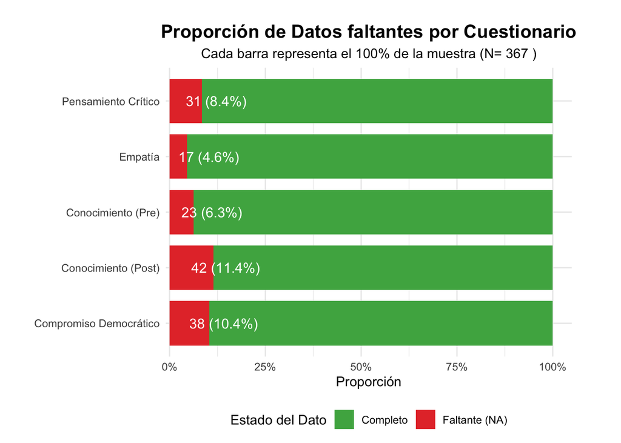

# Análisis descriptivo de los cuestionarios:

1. Pensamiento crítico
2. Empatía
3. Compromiso democrático 4️. Conocimiento general

## Análisis descriptivo de los cuestionarios

**Descriptivos por Grupo (A vs B)**

*Medias (M) y Desvíos Estándar (SD) por dominio*

| Grupo | N | **Pensamiento Crítico** M | **Pensamiento Crítico** SD | **Empatía** M | **Empatía** SD | **Compromiso Democrático** M | **Compromiso Democrático** SD | **Conocimiento (Post)** M | **Conocimiento (Post)** SD |
| --- | --- | --- | --- | --- | --- | --- | --- | --- | --- |
| A | 182.000 | 3.275 | 0.421 | 3.388 | 0.744 | 3.131 | 0.758 | 3.286 | 0.470 |
| B | 185.000 | 3.208 | 0.411 | 3.391 | 0.661 | 3.160 | 0.648 | 3.271 | 0.399 |

# Análisis descriptivo de conocimiento por caso

Ciencia, Ambiente, Desarrollo, Educación y Seguridad.

Descriptivos de conocimiento específico por grupo y caso

Tablas de conocimiento específico

**Análisis de conocimiento de casos por grupo**

*Medias (M) y Desvíos Estándar (SD) de puntajes post y delta*

| Grupo | N | Conocimiento POST (Total) Ciencia M (SD) | Conocimiento POST (Total) Ambiente M (SD) | Conocimiento POST (Total) Desarrollo M (SD) | Conocimiento POST (Total) Educación M (SD) | Conocimiento POST (Total) Seguridad M (SD) | Δ Conocimiento (Post − Pre) Ciencia M (SD) | Δ Conocimiento (Post − Pre) Ambiente M (SD) | Δ Conocimiento (Post − Pre) Desarrollo M (SD) | Δ Conocimiento (Post − Pre) Educación M (SD) | Δ Conocimiento (Post − Pre) Seguridad M (SD) |
| --- | --- | --- | --- | --- | --- | --- | --- | --- | --- | --- | --- |
| A | 182 | 6.044 (1.850) | 6.231 (2.144) | 6.308 (2.082) | 6.253 (2.277) | 5.923 (2.304) | −0.275 (2.049) | −0.324 (2.089) | −0.313 (2.140) | −0.264 (2.222) | −0.214 (2.332) |
| B | 185 | 6.043 (1.414) | 6.319 (1.906) | 6.411 (1.736) | 6.497 (1.942) | 6.168 (1.986) | −0.292 (1.557) | −0.395 (1.862) | −0.211 (1.606) | −0.254 (1.774) | −0.151 (1.574) |

Tabla de conocimiento total y delta por grupo y caso

**Conocimiento total y Δ por Grupo × Caso**

*Medias (M) y Desvíos Estándar (SD)*

| Grupo | Caso | N | Conocimiento Post M (SD) | Δ Conocimiento M (SD) |
| --- | --- | --- | --- | --- |
| A | AMBIENTE | 36 | 6.611 (2.296) | −0.194 (2.068) |
| A | DESARROLLO | 28 | 6.893 (1.257) | 0.179 (1.517) |
| A | EDUCACION | 44 | 6.432 (1.848) | −0.114 (1.588) |
| A | CIENCIA | 35 | 5.971 (1.948) | −0.114 (2.541) |
| A | SEGURIDAD | 34 | 6.088 (2.193) | −0.235 (1.860) |
| A | NA | 5 | NaN (NA) | NaN (NA) |
| B | AMBIENTE | 28 | 6.643 (1.545) | −0.214 (1.663) |
| B | DESARROLLO | 25 | 6.960 (1.513) | −0.520 (1.358) |
| B | EDUCACION | 43 | 6.302 (2.231) | −0.372 (1.890) |
| B | CIENCIA | 41 | 6.195 (1.308) | 0.024 (1.557) |
| B | SEGURIDAD | 45 | 6.422 (1.790) | 0.044 (1.476) |
| B | NA | 3 | NaN (NA) | NaN (NA) |

Grafico de conocimiento de caso por grupo

1. Grafico Conocimiento de caso “Media ± SE | A (Experimental) vs B (Control)”

**Comparación Pre vs. Post — Conocimiento general y específico por caso**

*Medias (M), desvíos (SD) y N por grupo*

| Grupo | Caso | Momento | N | M | SD |
| --- | --- | --- | --- | --- | --- |
| A | Ambiente | Post | 172 | 3.358 | 0.689 |
| A | Ambiente | Pre | 180 | 3.361 | 0.656 |
| B | Ambiente | Post | 179 | 3.318 | 0.716 |
| B | Ambiente | Pre | 185 | 3.397 | 0.711 |
| A | Ciencia | Post | 171 | 3.231 | 0.546 |
| A | Ciencia | Pre | 180 | 3.206 | 0.520 |
| B | Ciencia | Post | 179 | 3.123 | 0.445 |
| B | Ciencia | Pre | 185 | 3.186 | 0.515 |
| A | Desarrollo | Post | 172 | 3.366 | 0.709 |
| A | Desarrollo | Pre | 179 | 3.385 | 0.678 |
| B | Desarrollo | Post | 179 | 3.321 | 0.635 |
| B | Desarrollo | Pre | 185 | 3.324 | 0.657 |
| A | Educación | Post | 172 | 3.355 | 0.873 |
| A | Educación | Pre | 180 | 3.317 | 0.810 |
| B | Educación | Post | 179 | 3.383 | 0.748 |
| B | Educación | Pre | 185 | 3.389 | 0.728 |
| A | General | Post | 172 | 3.286 | 0.470 |
| A | General | Pre | 180 | 3.277 | 0.452 |
| B | General | Post | 179 | 3.271 | 0.399 |
| B | General | Pre | 185 | 3.295 | 0.400 |
| A | Seguridad | Post | 172 | 3.140 | 0.918 |
| A | Seguridad | Pre | 180 | 3.111 | 0.974 |
| B | Seguridad | Post | 179 | 3.204 | 0.815 |
| B | Seguridad | Pre | 185 | 3.189 | 0.856 |

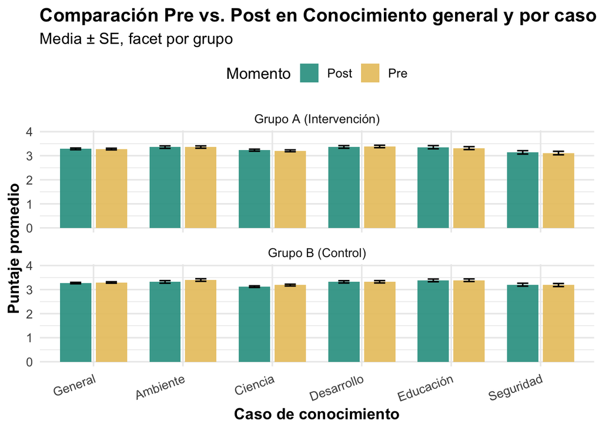

**Comparación Pre vs. Post — Conocimiento general y específico**

*Medias (M), desvíos (SD) y N por grupo*

| Grupo | Caso | Momento | N | M | SD |
| --- | --- | --- | --- | --- | --- |
| A | Ambiente | Post | 172 | 3.358 | 0.689 |
| A | Ambiente | Pre | 180 | 3.361 | 0.656 |
| B | Ambiente | Post | 179 | 3.318 | 0.716 |
| B | Ambiente | Pre | 185 | 3.397 | 0.711 |
| A | Ciencia | Post | 171 | 3.231 | 0.546 |
| A | Ciencia | Pre | 180 | 3.206 | 0.520 |
| B | Ciencia | Post | 179 | 3.123 | 0.445 |
| B | Ciencia | Pre | 185 | 3.186 | 0.515 |
| A | Desarrollo | Post | 172 | 3.366 | 0.709 |
| A | Desarrollo | Pre | 179 | 3.385 | 0.678 |
| B | Desarrollo | Post | 179 | 3.321 | 0.635 |
| B | Desarrollo | Pre | 185 | 3.324 | 0.657 |
| A | Educación | Post | 172 | 3.355 | 0.873 |
| A | Educación | Pre | 180 | 3.317 | 0.810 |
| B | Educación | Post | 179 | 3.383 | 0.748 |
| B | Educación | Pre | 185 | 3.389 | 0.728 |
| A | General | Post | 172 | 3.286 | 0.470 |
| A | General | Pre | 180 | 3.277 | 0.452 |
| B | General | Post | 179 | 3.271 | 0.399 |
| B | General | Pre | 185 | 3.295 | 0.400 |
| A | Seguridad | Post | 172 | 3.140 | 0.918 |
| A | Seguridad | Pre | 180 | 3.111 | 0.974 |
| B | Seguridad | Post | 179 | 3.204 | 0.815 |
| B | Seguridad | Pre | 185 | 3.189 | 0.856 |

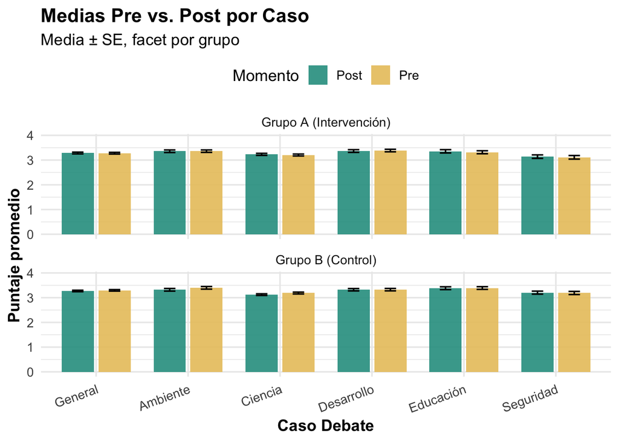

2. Gráfico de delta de conocimiento específico por grupo

[figure not shown]

# Analisis descriptivo de los ítems

## Frecuencia de respuestas centrales y extremas

Grafico de patrones de respuestas reordenado

Generar 5 graficos por cada cuestionario

[figure not shown]

```r
g_cono_pre
```

[figure not shown]

```r
g_cono_post
```

[figure not shown]

```r
g_pens
```

[figure not shown]

```r
g_empa
```

[figure not shown]

```r
g_comp
```

Tabla descriptiva de patrones de respuestas

```
## # A tibble: 52 × 7
##    Grupo        Caso  Cuestionario `% Centrales (3)` `% Extremo 1` `% Extremo 5`
##    <fct>        <fct> <fct>                    <dbl>         <dbl>         <dbl>
##  1 Experimenta… AMBI… Conocimient…              35.6           6.9          12.2
##  2 Control (B)  AMBI… Conocimient…              39.6           2.5          12.2
##  3 Experimenta… DESA… Conocimient…              38             6.9          15.9
##  4 Control (B)  DESA… Conocimient…              36.5           3.6          18.1
##  5 Experimenta… EDUC… Conocimient…              34.5           8.4          12.1
##  6 Control (B)  EDUC… Conocimient…              39.3           5.4           8.2
##  7 Experimenta… CIEN… Conocimient…              35.5           7            12.5
##  8 Control (B)  CIEN… Conocimient…              32.8           5.1           8.8
##  9 Experimenta… SEGU… Conocimient…              37.1           5            12.5
## 10 Control (B)  SEGU… Conocimient…              33.8           9.2          16.6
## 11 Experimenta… <NA>  Conocimient…              27.7          12.8          17
## 12 Control (B)  <NA>  Conocimient…              66.7           3.3          13.3
## 13 Experimenta… AMBI… Conocimient…              35             6.9          17.4
## 14 Control (B)  AMBI… Conocimient…              39.7           4             9.7
## 15 Experimenta… DESA… Conocimient…              37.2           7.2          16.2
## 16 Control (B)  DESA… Conocimient…              44             4            14.4
## 17 Experimenta… EDUC… Conocimient…              34.7           8.7          17.1
## 18 Control (B)  EDUC… Conocimient…              43             5.4          11.1
## 19 Experimenta… CIEN… Conocimient…              41.3           7.6          11.9
## 20 Control (B)  CIEN… Conocimient…              35.6           4.8          10.5
## # ℹ 32 more rows
## # ℹ 1 more variable: `% Extremos (1+5)` <dbl>
```

Frecuencia de respuestas centrales y extremas por grupo y caso

Comparación porcentual entre grupo experimental (A) y control (B)

| Grupo | Caso | % Centrales (3) | % Extremo 1 | % Extremo 5 | % Extremos (1+5) |
| --- | --- | --- | --- | --- | --- |
| Conocimiento (pre) |  |  |  |  |  |
| Experimental (A) | AMBIENTE | 35.6 | 6.9 | 12.2 | 19.2 |
| Control (B) | AMBIENTE | 39.6 | 2.5 | 12.2 | 14.7 |
| Experimental (A) | DESARROLLO | 38.0 | 6.9 | 15.9 | 22.8 |
| Control (B) | DESARROLLO | 36.5 | 3.6 | 18.1 | 21.7 |
| Experimental (A) | EDUCACION | 34.5 | 8.4 | 12.1 | 20.5 |
| Control (B) | EDUCACION | 39.3 | 5.4 | 8.2 | 13.6 |
| Experimental (A) | CIENCIA | 35.5 | 7.0 | 12.5 | 19.6 |
| Control (B) | CIENCIA | 32.8 | 5.1 | 8.8 | 13.9 |
| Experimental (A) | SEGURIDAD | 37.1 | 5.0 | 12.5 | 17.5 |
| Control (B) | SEGURIDAD | 33.8 | 9.2 | 16.6 | 25.7 |
| Experimental (A) | NA | 27.7 | 12.8 | 17.0 | 29.8 |
| Control (B) | NA | 66.7 | 3.3 | 13.3 | 16.7 |
| Conocimiento (post) |  |  |  |  |  |
| Experimental (A) | AMBIENTE | 35.0 | 6.9 | 17.4 | 24.3 |
| Control (B) | AMBIENTE | 39.7 | 4.0 | 9.7 | 13.7 |
| Experimental (A) | DESARROLLO | 37.2 | 7.2 | 16.2 | 23.5 |
| Control (B) | DESARROLLO | 44.0 | 4.0 | 14.4 | 18.4 |
| Experimental (A) | EDUCACION | 34.7 | 8.7 | 17.1 | 25.8 |
| Control (B) | EDUCACION | 43.0 | 5.4 | 11.1 | 16.5 |
| Experimental (A) | CIENCIA | 41.3 | 7.6 | 11.9 | 19.6 |
| Control (B) | CIENCIA | 35.6 | 4.8 | 10.5 | 15.3 |
| Experimental (A) | SEGURIDAD | 32.6 | 5.5 | 12.9 | 18.5 |
| Control (B) | SEGURIDAD | 39.6 | 8.1 | 14.1 | 22.1 |
| Pensamiento crítico |  |  |  |  |  |
| Experimental (A) | AMBIENTE | 46.9 | 0.0 | 0.0 | 0.0 |
| Control (B) | AMBIENTE | 47.3 | 5.4 | 0.0 | 5.4 |
| Experimental (A) | DESARROLLO | 46.7 | 1.8 | 0.0 | 1.8 |
| Control (B) | DESARROLLO | 51.0 | 0.0 | 0.0 | 0.0 |
| Experimental (A) | EDUCACION | 46.7 | 3.1 | 0.0 | 3.1 |
| Control (B) | EDUCACION | 52.2 | 1.6 | 0.0 | 1.6 |
| Experimental (A) | CIENCIA | 51.7 | 1.4 | 0.0 | 1.4 |
| Control (B) | CIENCIA | 59.8 | 0.0 | 0.0 | 0.0 |
| Experimental (A) | SEGURIDAD | 44.7 | 1.0 | 0.0 | 1.0 |
| Control (B) | SEGURIDAD | 48.5 | 3.4 | 0.0 | 3.4 |
| Empatía cognitiva |  |  |  |  |  |
| Experimental (A) | AMBIENTE | 24.9 | 4.8 | 17.2 | 22.0 |
| Control (B) | AMBIENTE | 20.7 | 9.1 | 22.0 | 31.1 |
| Experimental (A) | DESARROLLO | 29.9 | 6.0 | 23.4 | 29.3 |
| Control (B) | DESARROLLO | 25.3 | 4.7 | 20.7 | 25.3 |
| Experimental (A) | EDUCACION | 15.9 | 6.4 | 26.1 | 32.6 |
| Control (B) | EDUCACION | 24.8 | 9.7 | 17.8 | 27.5 |
| Experimental (A) | CIENCIA | 23.6 | 12.0 | 19.7 | 31.7 |
| Control (B) | CIENCIA | 22.4 | 4.5 | 22.0 | 26.4 |
| Experimental (A) | SEGURIDAD | 21.9 | 8.7 | 16.3 | 25.0 |
| Control (B) | SEGURIDAD | 23.0 | 8.9 | 19.6 | 28.5 |
| Compromiso democrático |  |  |  |  |  |
| Experimental (A) | AMBIENTE | 25.7 | 16.7 | 13.0 | 29.7 |
| Control (B) | AMBIENTE | 30.8 | 10.3 | 17.0 | 27.2 |
| Experimental (A) | DESARROLLO | 26.9 | 9.4 | 20.2 | 29.6 |
| Control (B) | DESARROLLO | 24.6 | 8.0 | 15.6 | 23.6 |
| Experimental (A) | EDUCACION | 23.3 | 11.2 | 21.9 | 33.1 |
| Control (B) | EDUCACION | 30.9 | 12.0 | 12.0 | 24.0 |
| Experimental (A) | CIENCIA | 29.7 | 13.5 | 16.9 | 30.5 |
| Control (B) | CIENCIA | 28.9 | 8.7 | 14.5 | 23.2 |
| Experimental (A) | SEGURIDAD | 28.3 | 12.7 | 16.8 | 29.5 |
| Control (B) | SEGURIDAD | 28.7 | 8.4 | 20.3 | 28.7 |

# Análisis comparativos

## Comparación entre grupos

# Análisis exploratorio de las variables

Estos análisis se llevan a cabo para identificar la distribución de las variables. Permiten confirmar si las características de sus valores cumplen con los requisitos para llevar a cabo los análisis de regresión posteriores.

1. Distribución y tendencia central de cada cuestionario Compara medias y desviaciones entre grupos (A/B).

**Descriptivos por grupo y dominio**

*Media (M), Desvío Estándar (SD) y N por dominio*

| Grupo | Dominio | N | M | SD |
| --- | --- | --- | --- | --- |
| A | Compromiso democrático | 177 | 3.131 | 0.758 |
| A | Conocimiento (post) | 172 | 3.286 | 0.470 |
| A | Conocimiento (pre) | 180 | 3.277 | 0.452 |
| A | Empatía cognitiva | 175 | 3.388 | 0.744 |
| A | Pensamiento crítico | 177 | 3.275 | 0.421 |
| B | Compromiso democrático | 181 | 3.160 | 0.648 |
| B | Conocimiento (post) | 179 | 3.271 | 0.399 |
| B | Conocimiento (pre) | 185 | 3.295 | 0.400 |
| B | Empatía cognitiva | 182 | 3.391 | 0.661 |
| B | Pensamiento crítico | 182 | 3.208 | 0.411 |

2. Correlaciones entre cuestionarios Este análisis permite observar asociaciones entre los distintos cuestionarios. La medida se expresa mediante el coeficiente de correlación de Pearson (r). Los valores cercanos a +1 indican una relación positiva fuerte (a medida que aumenta un puntaje, también lo hace el otro); Los valores cercanos a 0 indican ausencia de relación; Los valores negativos reflejarían relaciones inversas (no se observan en este caso).

**Correlaciones entre Cuestionarios**

*Coeficiente de correlación de Pearson (r)*

| Pares de Cuestionarios | *r* |
| --- | --- |
| Pensamiento crítico — Compromiso democrático | 0.424 |
| Compromiso democrático — Conocimiento general (post) | 0.327 |
| Empatía — Compromiso democrático | 0.313 |
| Pensamiento crítico — Empatía | 0.293 |
| Pensamiento crítico — Conocimiento general (post) | 0.265 |
| Empatía — Conocimiento general (post) | 0.140 |

**Interpretación:** - *r* = 0.50–0.69 (Corr. Fuerte) - *r* = 0.30–0.49 (Corr. Moderada) - *r* = 0.10–0.29 (Corr. Débil)

- Se observa una correlación moderada positiva (r = 0.42) entre Pensamiento crítico y Compromiso democrático, lo que sugiere que los/as participantes que razonan críticamente tienden también a reportar mayor compromiso cívico.
- Compromiso democrático también se asocia de manera moderada (r = 0.33) con Conocimiento general, indicando que quienes comprenden mejor los temas tratados reportan mayor compromiso cívico.
- Por último, la relación entre Conocimiento general y Empatía es muy débil (r = 0.14), indicando que ambos aspectos parecen funcionar de manera relativamente independiente.

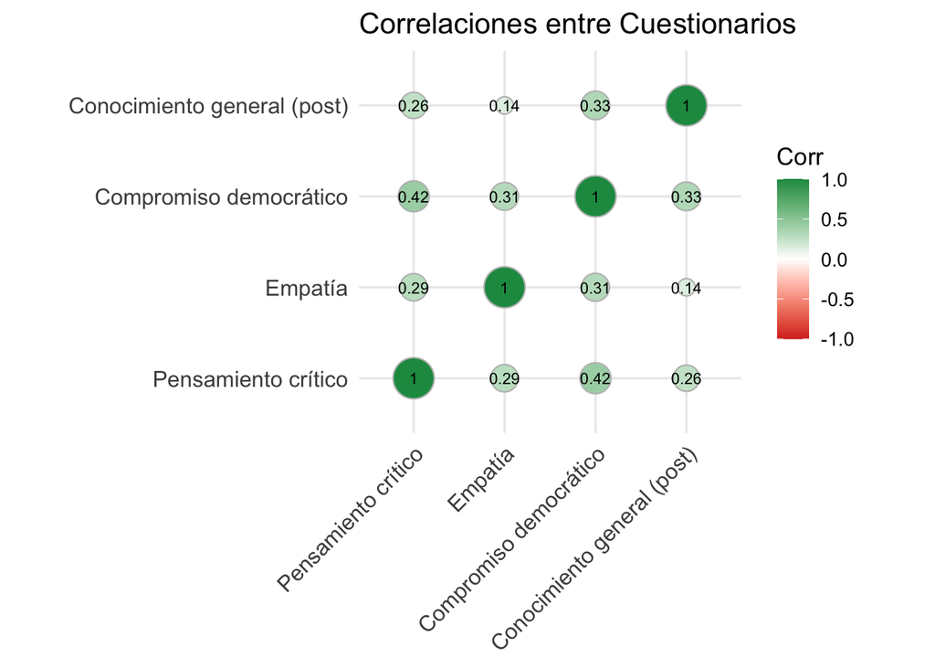

## 3. Outliers y homogeneidad de varianza

Detectaremos la presencia de valores extremos y dispersión de los datos.

|  | Df | F value | Pr(>F) |
| --- | --- | --- | --- |
| group | 1 | 5.81199 | 0.01641076 |
|  | 365 | NA | NA |

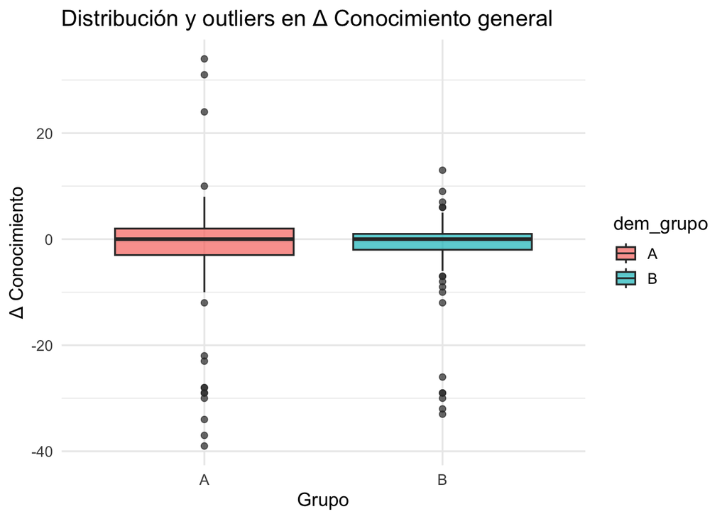

Tabla de prueba de Levene El Test de Levene (Brown–Forsythe) se utiliza para verificar la homogeneidad de varianzas entre los grupos antes de comparar sus medias. Si las varianzas entre grupos son iguales, se evidencia homocedasticidad. Este es un requisito para utilizar el análisis ANOVA y pruebas t).

**Test de Levene (Brown–Forsythe)**

*Prueba de homogeneidad de varianzas entre grupos en Δ Conocimiento general*

| Fuente de variación | gl | F | p |
| --- | --- | --- | --- |
| Entre grupos (A vs. B) | 1 | 5.812 | 0.0164 |
|  | 365 | — | — |

**Criterio de decisión:** si *p* < 0.05 se rechaza H₀. **Resultado:** Rechazo H₀ → Las varianzas difieren significativamente entre los grupos.

Nota: La primera fila muestra la comparación principal (Grupo A vs. Grupo B).  
La segunda fila corresponde a los residuos que representan la variabilidad interna que no está explicada por la agrupación.

En este caso, el valor obtenido fue F(1, 365) = 5.81, p = 0.016, lo que indica una diferencia significativa en las varianzas del cambio en conocimiento general (Δ Conocimiento) entre los grupos A (Experimental) y B (Control).

Esto implica que el grupo A mostró mayor variabilidad en la mejora del conocimiento en comparación con el grupo B, lo que sugiere una respuesta más heterogénea a la intervención. Esto debe tenerse en cuenta al interpretar los resultados de comparación de medias.

# Análisis comparativos

Dado el bajo número de participantes que se identificaron como no binarios (N=2) y los casos con datos faltantes (N=6), excluimos estos registros de los análisis comparativos por género, manteniendo únicamente las categorías Femenino (F) y Masculino (M) para garantizar la estabilidad estadística y la validez de las estimaciones.

Pruebas T.

A. T test para dos grupos

B. Pruebas T Pairwise para variables con ≥ 2 niveles (Género y Municipio)

C. Gráficos de medias ± SE variable

```r
plot_means_se <- function(data, vars, group_var, labels = var_labels, title){
  long <- data |>
    select(all_of(vars), all_of(group_var)) |>
    pivot_longer(cols = all_of(vars), names_to = "variable", values_to = "valor") |>
    mutate(variable = factor(variable, levels = vars, labels = labels[vars]))

  sumdat <- long %>%
    group_by(variable, .data[[group_var]]) %>%
    summarise(
      media = mean(valor, na.rm = TRUE),
      se = sd(valor, na.rm = TRUE)/sqrt(sum(!is.na(valor))),
      .groups = "drop"
    )

  ylim_max <- max(sumdat$media + sumdat$se, na.rm = TRUE) * 1.12

  ggplot(sumdat, aes(x = .data[[group_var]], y = media, fill = .data[[group_var]])) +
    geom_col(width = 0.6, alpha = 0.85) +
    geom_errorbar(aes(ymin = media - se, ymax = media + se), width = 0.2) +
    facet_wrap(~variable, scales = "free_y") +
    labs(title = title, x = NULL, y = "Media ± SE") +
    expand_limits(y = ylim_max) +
    scale_fill_discrete(name = group_var) +
    theme_minimal(base_size = 12) +
    theme(legend.position = "top",
          plot.title = element_text(face = "bold"),
          axis.text.x = element_text(angle = 15, hjust = 1))
}
```

Comparaciones por grupo (A y B)

**Comparación de medias (t-test Welch) — Conocimiento general**

*Agrupador: `dem_grupo`*

| Variable | Grupo | n | M | SD | Grupo | n | M | SD | t | gl | p | Cohen's d |
| --- | --- | --- | --- | --- | --- | --- | --- | --- | --- | --- | --- | --- |
| Conocimiento general (post) | A | 172 | 3.286 | 0.470 | B | 179 | 3.271 | 0.399 | 0.327 | 335.159 | 0.744 | 0.035 |

**Criterio:** *p* < .05 → diferencia significativa. Efecto: *d* ≈0.2 pequeño, 0.5 mediano, 0.8 grande.

**Comparación de medias (t-test Welch) — Conocimiento específico**

*Agrupador: `dem_grupo`*

| Variable | Grupo | n | M | SD | Grupo | n | M | SD | t | gl | p | Cohen's d |
| --- | --- | --- | --- | --- | --- | --- | --- | --- | --- | --- | --- | --- |
| Conocimiento — Ambiente (post) | A | 172 | 3.358 | 0.689 | B | 179 | 3.318 | 0.716 | 0.521 | 348.999 | 0.602 | 0.056 |
| Conocimiento — Ciencia (post) | A | 171 | 3.231 | 0.546 | B | 179 | 3.123 | 0.445 | 2.025 | 328.223 | 0.044 | 0.217 |
| Conocimiento — Desarrollo (post) | A | 172 | 3.366 | 0.709 | B | 179 | 3.321 | 0.635 | 0.626 | 341.390 | 0.532 | 0.067 |
| Conocimiento — Educación (post) | A | 172 | 3.355 | 0.873 | B | 179 | 3.383 | 0.748 | −0.322 | 336.435 | 0.747 | −0.034 |
| Conocimiento — Seguridad (post) | A | 172 | 3.140 | 0.918 | B | 179 | 3.204 | 0.815 | −0.694 | 340.500 | 0.488 | −0.074 |

**Criterio:** *p* < .05 → diferencia significativa. Efecto: *d* ≈0.2 pequeño, 0.5 mediano, 0.8 grande.

**Comparación de medias (t-test Welch) — Cuestionarios**

*Agrupador: `dem_grupo`*

| Variable | Grupo | n | M | SD | Grupo | n | M | SD | t | gl | p | Cohen's d |
| --- | --- | --- | --- | --- | --- | --- | --- | --- | --- | --- | --- | --- |
| Pensamiento crítico | A | 177 | 3.275 | 0.421 | B | 182 | 3.208 | 0.411 | 1.531 | 356.094 | 0.127 | 0.162 |
| Empatía | A | 175 | 3.388 | 0.744 | B | 182 | 3.391 | 0.661 | −0.046 | 346.352 | 0.964 | −0.005 |
| Compromiso democrático | A | 177 | 3.131 | 0.758 | B | 181 | 3.160 | 0.648 | −0.386 | 344.994 | 0.700 | −0.041 |

**Criterio:** *p* < .05 → diferencia significativa. Efecto: *d* ≈0.2 pequeño, 0.5 mediano, 0.8 grande.

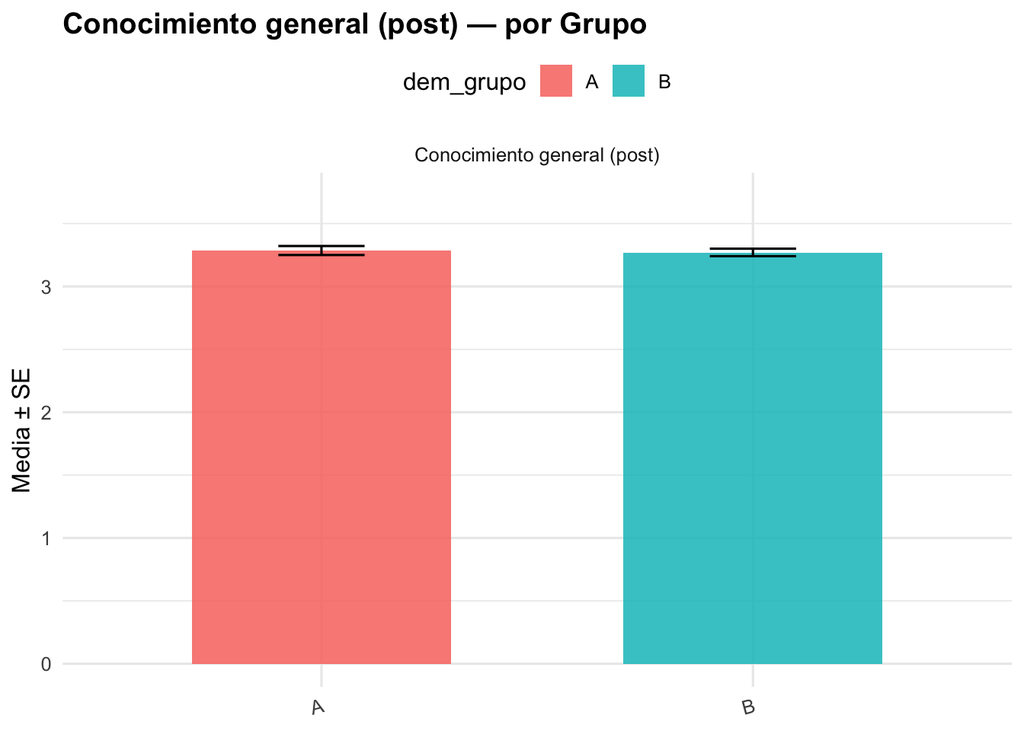

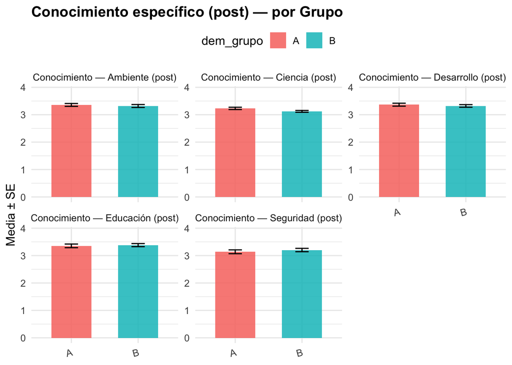

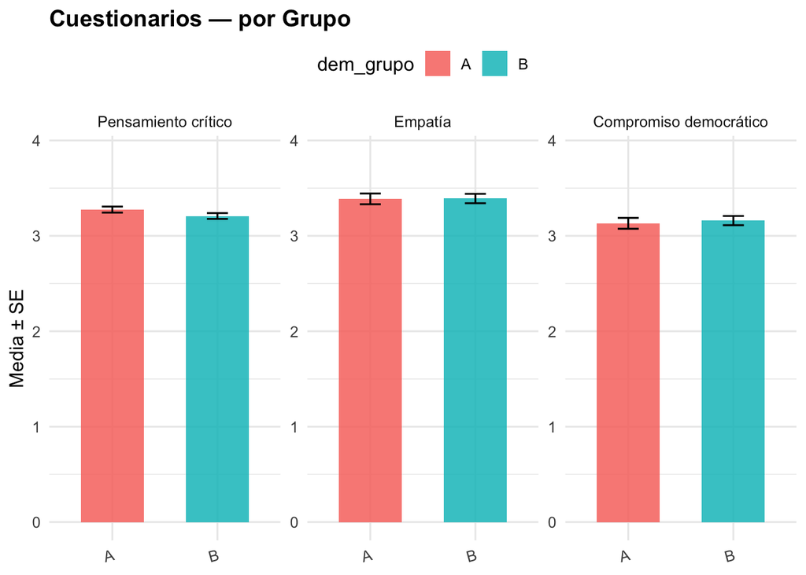

Comparación ente Género

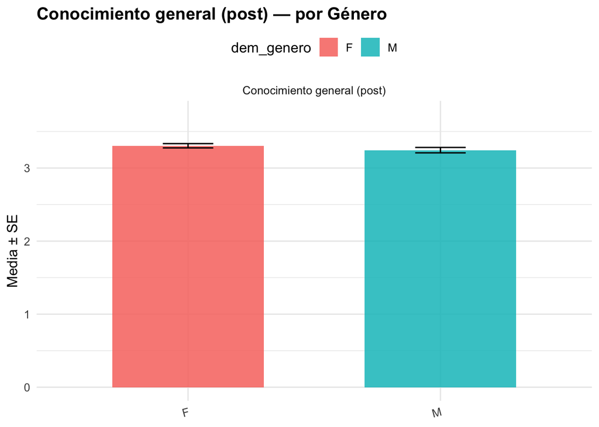

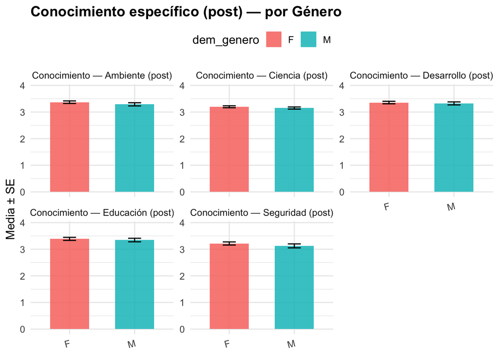

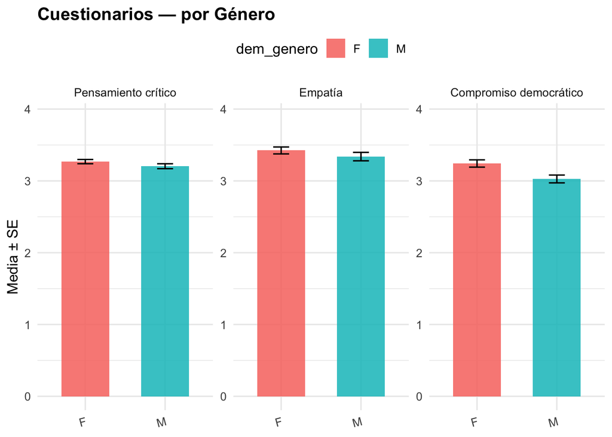

Comparación entre municipios

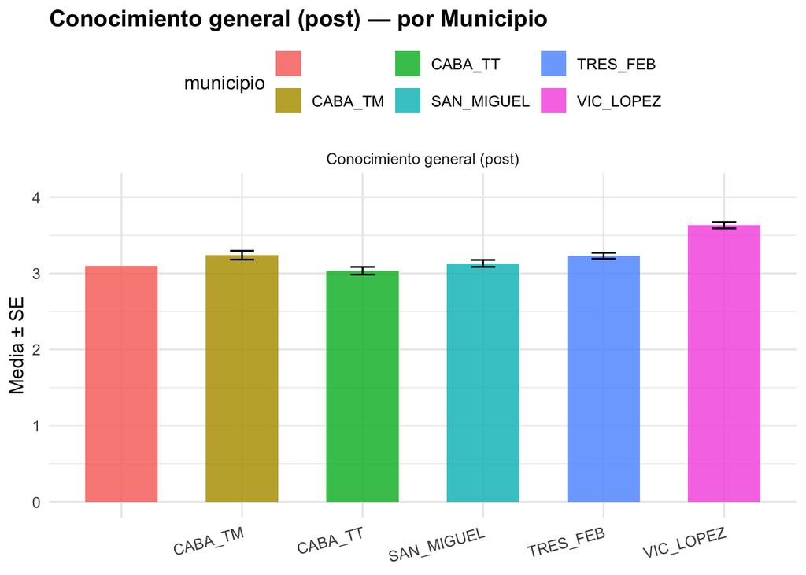

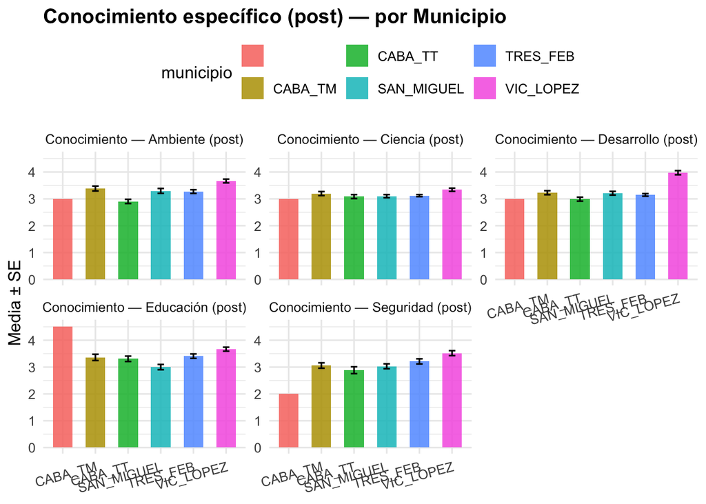

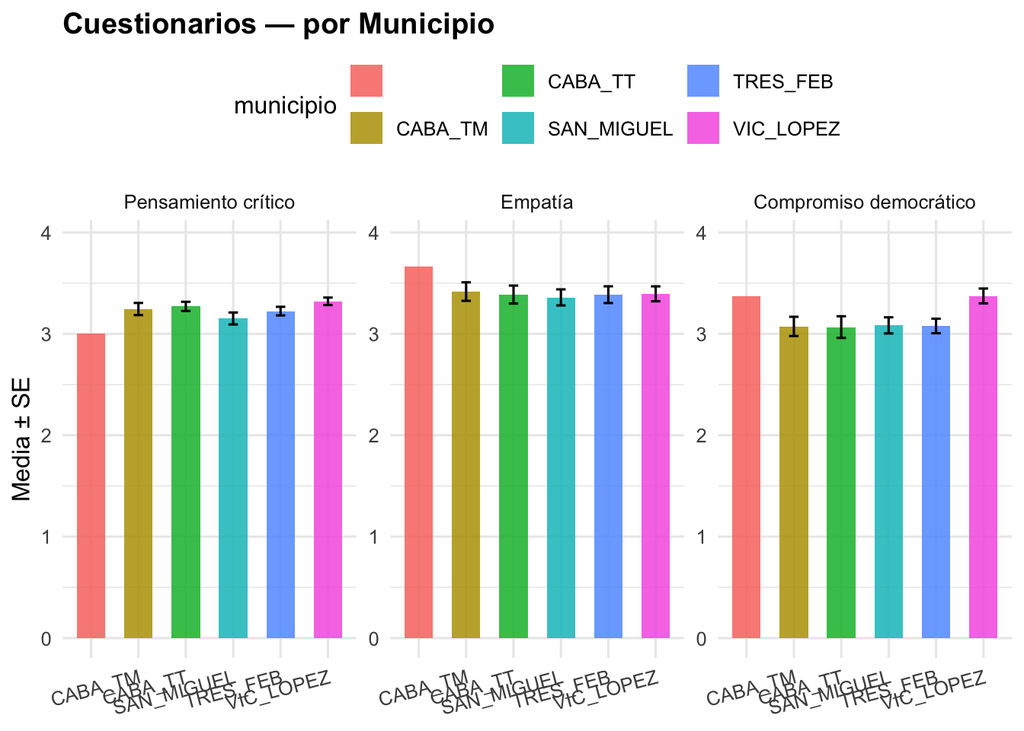

# ANOVA

El ANOVA (Análisis de Varianza) permite comparar medias entre dos o más grupos evaluando si las diferencias observadas son mayores a lo esperable por azar. Con un factor (p.ej., Género o Municipio), el ANOVA de un factor contrasta si existe diferencia promedio entre sus niveles. Si el factor tiene ≥3 niveles, se complementa con comparaciones post hoc (Tukey) para identificar qué pares difieren. Variables analizadas Conocimiento: general (post) y específico por caso (Ambiente, Ciencia, Desarrollo, Educación, Seguridad). Cuestionarios actitudinales: Pensamiento crítico, Empatía, Compromiso democrático. Qué reportamos Estadístico F, gl, y p (significancia). Tamaño de efecto (η² o η² parcial) para cuantificar la magnitud práctica. Si hay ≥3 niveles y efecto significativo: post hoc de Tukey con p ajustada y IC95% de las diferencias. Gráficos de medias ± SE por nivel del factor (y, en dos factores, por Grupo × Caso). Supuestos (evaluados con Levene): Independencia de observaciones, Normalidad (residuos ~ normales; robusto con tamaños moderados), Homoscedasticidad (como nuestros datos no presentan varianzas similares, aplicaremos analisis de Welch y transformaciones además de modelos mixtos).

Anova Genero

```r
# Re-correr el chunk donde se define la función
post_genero <- anova_posthoc_tukey_table(datos_genero_filtrado, vars_anova, "dem_genero", title_suffix = " — Género")
post_genero  # debería renderizar tabla gt
```

**Post hoc Tukey — Género**

*Comparaciones pareadas por `dem_genero`*

| Variable | Grupo 1 | Grupo 2 | Dif. Medias | IC95% (bajo) | IC95% (alto) | p (aj.) |
| --- | --- | --- | --- | --- | --- | --- |
| Conocimiento general (post) | F | M | −0.060 | −0.152 | 0.032 | 0.201 |
| Conocimiento — Ambiente (post) | F | M | −0.081 | −0.230 | 0.068 | 0.285 |
| Conocimiento — Ciencia (post) | F | M | −0.047 | −0.154 | 0.059 | 0.383 |
| Conocimiento — Desarrollo (post) | F | M | −0.033 | −0.176 | 0.111 | 0.653 |
| Conocimiento — Educación (post) | F | M | −0.043 | −0.216 | 0.129 | 0.622 |
| Conocimiento — Seguridad (post) | F | M | −0.090 | −0.275 | 0.094 | 0.335 |
| Pensamiento crítico | F | M | −0.064 | −0.153 | 0.024 | 0.154 |
| Empatía | F | M | −0.086 | −0.233 | 0.062 | 0.255 |
| Compromiso democrático | F | M | −0.215 | −0.362 | −0.069 | 0.004 |

**Criterio:** *p (aj.)* < .05 → diferencia significativa (ajuste Tukey).

```r
gtsave(post_genero,
  filename = "tabla_post_genero.png", vwidth = 1600, vheight = 900 )
```

```
## file:////var/folders/09/t6dgts6s69j7r8hbykbdg0rm0000gn/T//Rtmpd1NocM/fileaa003416a710.html screenshot completed
```

**ANOVA de un factor — Género**

*Factor: `dem_genero`*

| Variable | Factor | F | gl₁ | gl₂ | p | η² |
| --- | --- | --- | --- | --- | --- | --- |
| Conocimiento general (post) | dem_genero | 1.644 | 1.000 | 342.000 | 0.201 | 0.005 |
| Conocimiento — Ambiente (post) | dem_genero | 1.147 | 1.000 | 342.000 | 0.285 | 0.003 |
| Conocimiento — Ciencia (post) | dem_genero | 0.762 | 1.000 | 341.000 | 0.383 | 0.002 |
| Conocimiento — Desarrollo (post) | dem_genero | 0.203 | 1.000 | 342.000 | 0.653 | 0.001 |
| Conocimiento — Educación (post) | dem_genero | 0.243 | 1.000 | 342.000 | 0.622 | 0.001 |
| Conocimiento — Seguridad (post) | dem_genero | 0.933 | 1.000 | 342.000 | 0.335 | 0.003 |
| Pensamiento crítico | dem_genero | 2.045 | 1.000 | 349.000 | 0.154 | 0.006 |
| Empatía | dem_genero | 1.298 | 1.000 | 347.000 | 0.255 | 0.004 |
| Compromiso democrático | dem_genero | 8.337 | 1.000 | 348.000 | 0.004 | 0.023 |

**Criterio:** *p* < .05 → diferencia significativa. Tamaño de efecto (η²): 0.01 pequeño, 0.06 mediano, 0.14 grande.

**Post hoc Tukey — Género**

*Comparaciones pareadas por `dem_genero`*

| Variable | Grupo 1 | Grupo 2 | Dif. Medias | IC95% (bajo) | IC95% (alto) | p (aj.) |
| --- | --- | --- | --- | --- | --- | --- |
| Conocimiento general (post) | F | M | −0.060 | −0.152 | 0.032 | 0.201 |
| Conocimiento — Ambiente (post) | F | M | −0.081 | −0.230 | 0.068 | 0.285 |
| Conocimiento — Ciencia (post) | F | M | −0.047 | −0.154 | 0.059 | 0.383 |
| Conocimiento — Desarrollo (post) | F | M | −0.033 | −0.176 | 0.111 | 0.653 |
| Conocimiento — Educación (post) | F | M | −0.043 | −0.216 | 0.129 | 0.622 |
| Conocimiento — Seguridad (post) | F | M | −0.090 | −0.275 | 0.094 | 0.335 |
| Pensamiento crítico | F | M | −0.064 | −0.153 | 0.024 | 0.154 |
| Empatía | F | M | −0.086 | −0.233 | 0.062 | 0.255 |
| Compromiso democrático | F | M | −0.215 | −0.362 | −0.069 | 0.004 |

**Criterio:** *p (aj.)* < .05 → diferencia significativa (ajuste Tukey).

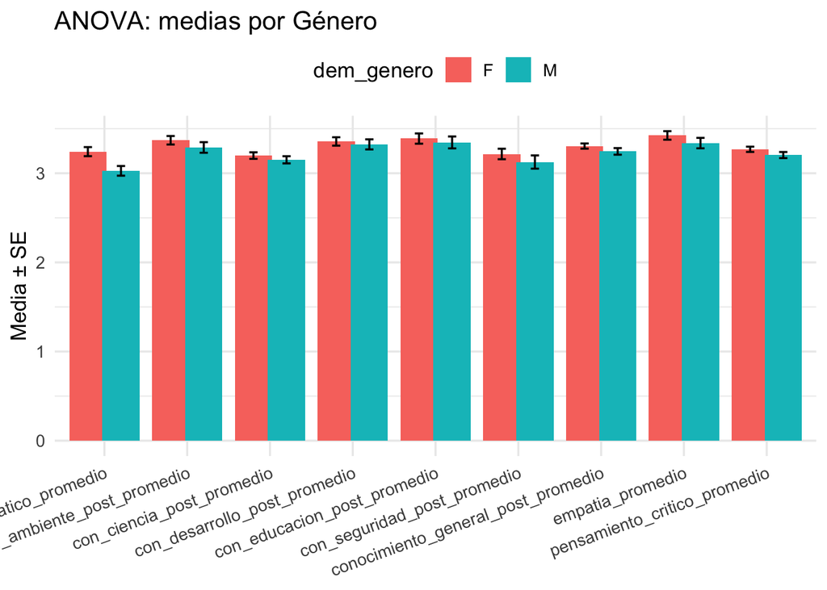

Anova Municipio

**ANOVA de un factor — Municipio**

*Factor: `municipio`*

| Variable | Factor | F | gl₁ | gl₂ | p | η² |
| --- | --- | --- | --- | --- | --- | --- |
| Conocimiento general (post) | municipio | 19.953 | 5.000 | 345.000 | 0.000 | 0.224 |
| Conocimiento — Ambiente (post) | municipio | 8.207 | 5.000 | 345.000 | 0.000 | 0.106 |
| Conocimiento — Ciencia (post) | municipio | 2.689 | 5.000 | 344.000 | 0.021 | 0.038 |
| Conocimiento — Desarrollo (post) | municipio | 26.599 | 5.000 | 345.000 | 0.000 | 0.278 |
| Conocimiento — Educación (post) | municipio | 5.917 | 5.000 | 345.000 | 0.000 | 0.079 |
| Conocimiento — Seguridad (post) | municipio | 4.888 | 5.000 | 345.000 | 0.000 | 0.066 |
| Pensamiento crítico | municipio | 1.420 | 5.000 | 353.000 | 0.216 | 0.020 |
| Empatía | municipio | 0.077 | 5.000 | 351.000 | 0.996 | 0.001 |
| Compromiso democrático | municipio | 2.318 | 5.000 | 352.000 | 0.043 | 0.032 |

**Criterio:** *p* < .05 → diferencia significativa. Tamaño de efecto (η²): 0.01 pequeño, 0.06 mediano, 0.14 grande.

**Post hoc Tukey — Municipio**

*Comparaciones pareadas por `municipio`*

| Variable | Grupo 1 | Grupo 2 | Dif. Medias | IC95% (bajo) | IC95% (alto) | p (aj.) |
| --- | --- | --- | --- | --- | --- | --- |
| Conocimiento general (post) |  | CABA_TM | 0.138 | −0.976 | 1.251 | 0.999 |
| Conocimiento general (post) |  | CABA_TT | −0.066 | −1.183 | 1.050 | 1.000 |
| Conocimiento general (post) |  | SAN_MIGUEL | 0.030 | −1.082 | 1.143 | 1.000 |
| Conocimiento general (post) |  | TRES_FEB | 0.130 | −0.980 | 1.241 | 0.999 |
| Conocimiento general (post) |  | VIC_LOPEZ | 0.532 | −0.579 | 1.644 | 0.743 |
| Conocimiento general (post) | CABA_TM | CABA_TT | −0.204 | −0.418 | 0.011 | 0.073 |
| Conocimiento general (post) | CABA_TM | SAN_MIGUEL | −0.107 | −0.301 | 0.087 | 0.610 |
| Conocimiento general (post) | CABA_TM | TRES_FEB | −0.007 | −0.190 | 0.175 | 1.000 |
| Conocimiento general (post) | CABA_TM | VIC_LOPEZ | 0.395 | 0.208 | 0.582 | 0.000 |
| Conocimiento general (post) | CABA_TT | SAN_MIGUEL | 0.097 | −0.112 | 0.305 | 0.772 |
| Conocimiento general (post) | CABA_TT | TRES_FEB | 0.197 | −0.001 | 0.395 | 0.053 |
| Conocimiento general (post) | CABA_TT | VIC_LOPEZ | 0.599 | 0.396 | 0.801 | 0.000 |
| Conocimiento general (post) | SAN_MIGUEL | TRES_FEB | 0.100 | −0.076 | 0.276 | 0.579 |
| Conocimiento general (post) | SAN_MIGUEL | VIC_LOPEZ | 0.502 | 0.321 | 0.683 | 0.000 |
| Conocimiento general (post) | TRES_FEB | VIC_LOPEZ | 0.402 | 0.234 | 0.570 | 0.000 |
| Conocimiento — Ambiente (post) |  | CABA_TM | 0.385 | −1.547 | 2.318 | 0.993 |
| Conocimiento — Ambiente (post) |  | CABA_TT | −0.096 | −2.033 | 1.842 | 1.000 |
| Conocimiento — Ambiente (post) |  | SAN_MIGUEL | 0.297 | −1.634 | 2.228 | 0.998 |
| Conocimiento — Ambiente (post) |  | TRES_FEB | 0.272 | −1.656 | 2.199 | 0.999 |
| Conocimiento — Ambiente (post) |  | VIC_LOPEZ | 0.667 | −1.262 | 2.596 | 0.921 |
| Conocimiento — Ambiente (post) | CABA_TM | CABA_TT | −0.481 | −0.853 | −0.109 | 0.003 |
| Conocimiento — Ambiente (post) | CABA_TM | SAN_MIGUEL | −0.088 | −0.425 | 0.249 | 0.975 |
| Conocimiento — Ambiente (post) | CABA_TM | TRES_FEB | −0.114 | −0.430 | 0.203 | 0.908 |
| Conocimiento — Ambiente (post) | CABA_TM | VIC_LOPEZ | 0.281 | −0.044 | 0.606 | 0.132 |
| Conocimiento — Ambiente (post) | CABA_TT | SAN_MIGUEL | 0.393 | 0.030 | 0.755 | 0.025 |
| Conocimiento — Ambiente (post) | CABA_TT | TRES_FEB | 0.367 | 0.024 | 0.711 | 0.028 |
| Conocimiento — Ambiente (post) | CABA_TT | VIC_LOPEZ | 0.762 | 0.411 | 1.114 | 0.000 |
| Conocimiento — Ambiente (post) | SAN_MIGUEL | TRES_FEB | −0.025 | −0.331 | 0.280 | 1.000 |
| Conocimiento — Ambiente (post) | SAN_MIGUEL | VIC_LOPEZ | 0.370 | 0.056 | 0.684 | 0.011 |
| Conocimiento — Ambiente (post) | TRES_FEB | VIC_LOPEZ | 0.395 | 0.103 | 0.687 | 0.002 |

[output cut: 105 more lines]

**Criterio:** *p (aj.)* < .05 → diferencia significativa (ajuste Tukey).

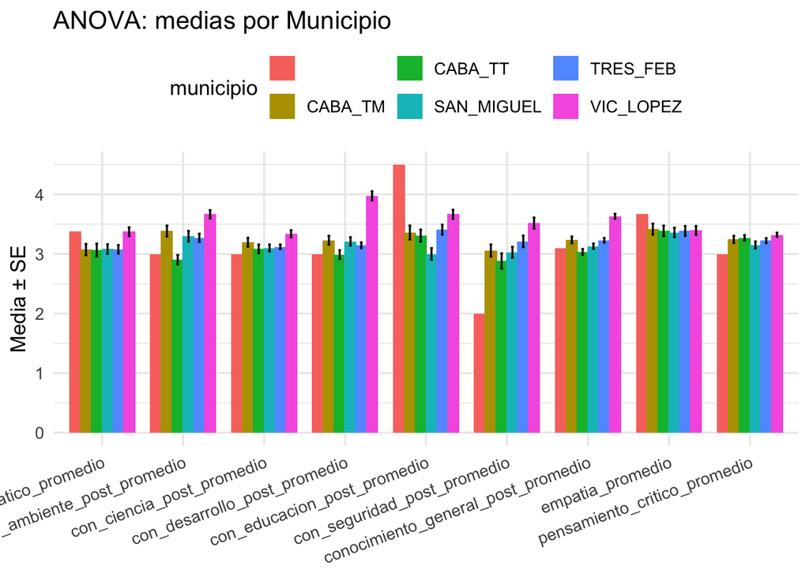

# Resultados del Análisis ANOVA para evaluar diferencias en los cuestionarios según municipios.

## Conocimiento general (post):

F(5,345) = 19.95, p < .001, η² = .224 Indica diferencias significativas y de tamaño de efecto grande entre municipios. Es decir, el nivel de conocimiento general difiere sustancialmente según el municipio. ## Conocimiento — Desarrollo (post): F(5,345) = 26.60, p < .001, η² = .278 Representa diferencias muy significativas y de efecto muy grande. Este parece ser el dominio con mayor variabilidad entre municipios.

## Conocimiento — Ambiente, Educación y Seguridad (post):

p < .05 en los tres casos, con η² entre .066 y .106 Sugiere diferencias moderadas entre municipios.

## Conocimiento — Ciencia (post):

p = .021, η² = .038

Presenta diferencias significativas pero de tamaño de efecto pequeño.

## Pensamiento crítico, Empatía y Compromiso democrático:

p > .05 (excepto Compromiso democrático, p = .043, η² = .032)

No se observan diferencias significativas entre municipios para estos cuestionarios, o son de efecto pequeño.